# Homework 4

Author: Matthew J. Cossley

Last update: 13 March, 2022

## 0.

```r
# load the packages we will need
library(data.table)
library(ggplot2)

# clean session
rm(list=ls())

# basic id info
my_name <- "John Doe"
my_student_id <- "12345678"

# Please include the following line of code as well
set.seed(0)
```

## 1.

Consider the following two random variables:

- $X\sim\mathcal{N}(\mu=0,\sigma=1)$
- $Y{\sim}Binom(n=10,p=0.2)$

The $X$ probability distribution (pdf since $X$ is continuous) and the $Y$ probability distribution (pmf since $Y$ is discrete) are illustrated below. The probability corresponding to $x{\leq}1$ and $y{\leq}3$ (`lower.tail=TRUE`) are coloured blue and the the probability corresponding to $x{>}1$ and $y{>}3$ (`lower.tail=FALSE`) are coloured green. This figure is only here to help you think about what is being asked below.

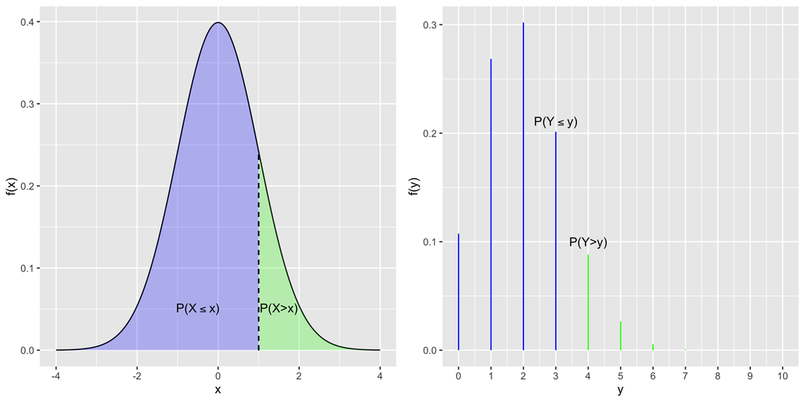

Are the following statements `TRUE` or `FALSE`?

**(a)** $p(X{<}x)=p(X{\leq}x)$ for all $x$.

```r
# uncomment the correct answer
# ans_1a <- TRUE
# ans_1a <- FALSE
```

**(b)** $p(Y < y) = p(Y\leq y)$ for all $y$.

```r
# uncomment the correct answer
# ans_1b <- TRUE
# ans_1b <- FALSE
```

**(c)** $p(X < x) = 1 - p(X > x)$ for all $x$.

```r
# uncomment the correct answer
# ans_1c <- TRUE
# ans_1c <- FALSE
```

**(d)** $p(Y < y) = 1 - p(Y > y)$ for all $y$.

```r
# uncomment the correct answer
# ans_1d <- TRUE
# ans_1d <- FALSE
```

## 2.

Consider the following random variables:

- $X{\sim}\mathcal{N}(\mu_X=15,\sigma_X=2.74)$
- $Y{\sim}Binom(n=30,p=0.5)$.

The $X$ and $Y$ distributions are illustrated in the following figure:

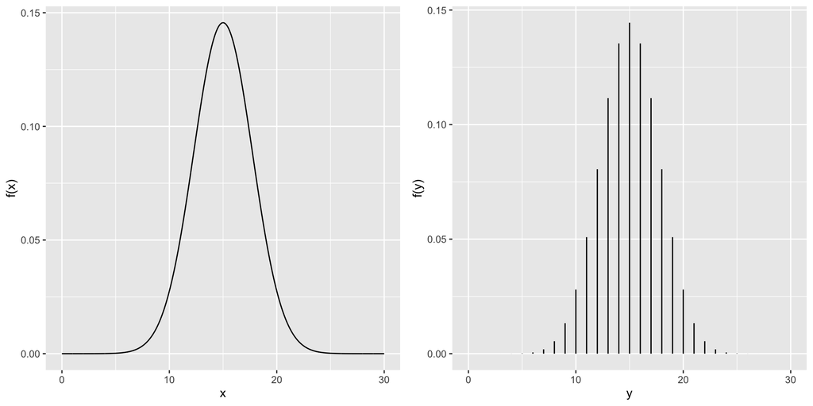

For all of the following use built-in `R` functions to compute the requested quantities. The functions are covered in the lecture notes this week.

**(a)** Compute $P(X > 17)$ and store it in a variable named `ans_2a`.

**(b)** Compute $P(X \leq 14)$ and store it in a variable named `ans_2b`.

**(c)** Compute $P(X \geq 20)$ and store it in a variable named `ans_2c`.

**(d)** Compute $P(X < 13)$ and store it in a variable named `ans_2d`.

**(e)** Compute $P(Y > 17)$ and store it in a variable named `ans_2e`.

**(f)** Compute $P(Y \leq 14)$ and store it in a variable named `ans_2f`.

**(g)** Compute $P(Y \geq 20)$ and store it in a variable named `ans_2g`.

**(h)** Compute $P(Y < 13)$ and store it in a variable named `ans_2h`.

**(i)** How do all of the above quantities computed with respect to $X$ compare to those computed with respect to $Y$? No points for this one. Just think about it.

## 3.

Consider the following plots:

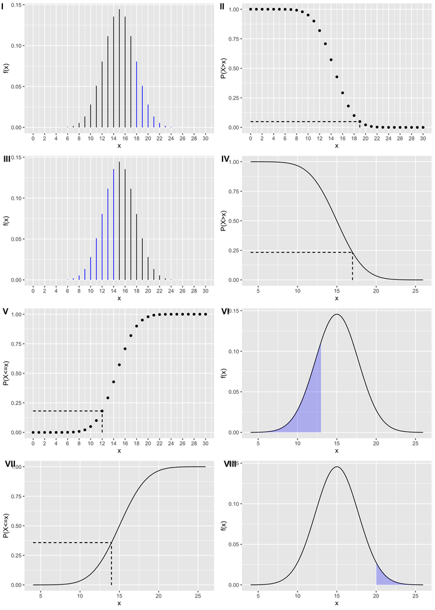

For each of the following problems, please respond by setting the appropriate variable to one of `"I"`, `"II"`, `"III"`, `"IV"`, `"V"`, `"VI"`, `"VII"`, or `"VIII"`. When responding to the questions below, please note that the x and y axis labels in the above plots all use ‘X’ or ‘x’ but may correspond to either the X or the Y random variable from problem 2.

**(a)** Which plot corresponds to the quantity requested in problem 2a? Please store your answer in a variable named `ans_3a`.

**(b)** Which plot corresponds to the quantity requested in problem 2b? Please store your answer in a variable named `ans_3b`.

**(c)** Which plot corresponds to the quantity requested in problem 2c? Please store your answer in a variable named `ans_3c`.

**(d)** Which plot corresponds to the quantity requested in problem 2d? Please store your answer in a variable named `ans_3d`.

**(e)** Which plot corresponds to the quantity requested in problem 2e? Please store your answer in a variable named `ans_3e`.

**(f)** Which plot corresponds to the quantity requested in problem 2f? Please store your answer in a variable named `ans_3f`.

**(g)** Which plot corresponds to the quantity requested in problem 2g? Please store your answer in a variable named `ans_3g`.

**(h)** Which plot corresponds to the quantity requested in problem 2h? Please store your answer in a variable named `ans_3h`.

## 4.

Consider the random variable $X{\sim}F(d_1,d_2)$ with fixed parameters $d_1=5$, $d_2=100$. Given these values of $d_1$ and $d_2$, the following holds true:

$$\text{if } X \sim F(d_1,d_2)\text{ then:}\\
\mathbb{E}[X] = \frac{d_2}{d_2 - 2} \\
\mathbb{V}\text{ar}[X] = \frac{2 d_2^2 (d_1 + d_2 - 2)}{d_1 (d_2 - 2)^2 (d_2 - 4)}$$

You might need numerical values for $\mathbb{E}[X]$ and $\mathbb{V}\text{ar}[X]$ later in this problem. If you do, you can compute them with the following code chunk:

```r
d1 <- 5
d2 <- 100

mu_x <- (d2/(d2-2))
sig_x <- (2*(d2^2)*(d1+d2-2))/(d1*(d2-2)^2*(d2-4))
```

We next perform 6 experiments. In each experiment, we draw 1000 samples from $X$ and plot a histogram for the results of each experiment. The results of these experiments are shown in the following histograms.

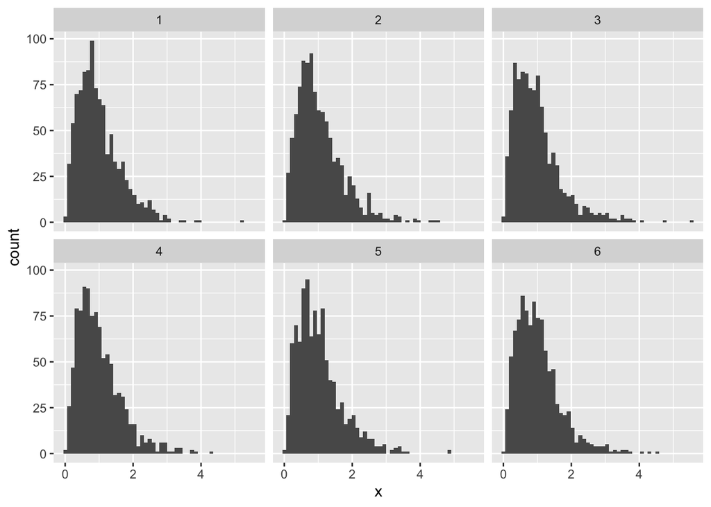

**(a)**Do the histograms appear Normally distributed? If not, what is the main difference? Please respond with one of the following:

- `ans_4a <- "Skewed"`
- `ans_4a <- "Normal"`

We next estimate the distribution of sample means as a function of the number of samples `n` that were drawn per experiment. We will perform 6 experiments in which we draw 2, 5, 10, 15, 30, and 50 samples from $X$ (each of these numbers corresponds to one experiment). Each of these experiments, if performed once, will give us one sample mean. To examine the distribution of sample means, we repeat each experiment 1000 times. This will give us 1000 sample means per experiment. For each experiment, we estimate the distribution of sample means with a histogram and make a single figure with separate panels for each experiment to show our results.

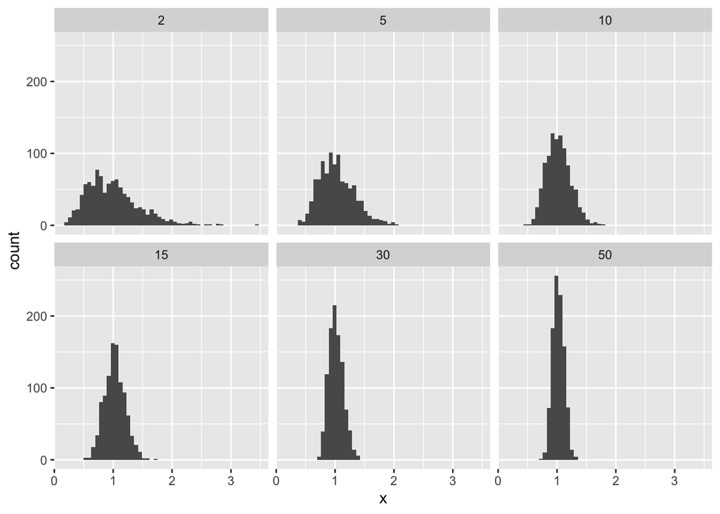

**(b)** What happens to the variance of the distribution of sample means as $n$ increases?

- `ans_4b <- "Stays the same"`
- `ans_4b <- "Increases"`
- `ans_4b <- "Decreases"`

**(c)** What happens to the skew of the distribution of sample means as $n$ increases?

- `ans_4c <- "Stays the same"`
- `ans_4c <- "Increases"`
- `ans_4c <- "Decreases"`

**(d)** If $X{\sim}F(d_1,d_2)$ as defined at the top of the problem, and $n=1000$, what is the population mean of $\bar{X}$ (the distribution of sample means)? Store your answer in a variable named `ans_4d`.

**(e)** If $X{\sim}F(d_1,d_2)$ as defined at the top of the problem, and $n=1000$, what is the population variance of $\bar{X}$ (the distribution of sample means)? Store your answer in a variable named `ans_4e`.

## 5. Final Check

A common error on these problem sets is to accidentally erase or overwrite variables from one question with those from another. Another common error is to name your variables slightly wrong (e.g., `Ans_1a` instead of `ans_1a`). Yet another common error is to include a line of code or two that generates an error, and sometimes this error is serious enough to prevent most or all of your script from running, in which case you will lose most or all of your marks for that assignment. All of these can be a very frustrating way to lose marks, but you will indeed lose marks if you make these mistakes, so you need to be very careful!

To ensure that this doesn’t happen to you, please run your entire `.R` script from start to finish. One way to do this is to use `Code > Run Region > Run All`, but of course there are shortcuts for everything so do as you wish. If there are any errors at all when you do this, it is essential that you address them.

After all of your code has executed from start to finish without and errors at all, then carefully inspect your workspace to ensure that the following variables are defined. A reasonable way to do this is to try to print each one of these variables to the console. If it is defined, then it will print without error.

```r
my_name
my_student_id
ans_1a
ans_1b
ans_1c
ans_1d
ans_2a
ans_2b
ans_2c
ans_2d
ans_2e
ans_2f
ans_2g
ans_2h
ans_3a
ans_3b
ans_3c
ans_3d
ans_3e
ans_3f
ans_3g
ans_3h
ans_4a
ans_4b
ans_4c
ans_4d
ans_4e
```

Finally, be sure that the file you submit to iLearn is a `.R` file and nothing else. Any other extension cannot be marked. This means do not submit `.Rmd`, `.RProj`, `.pdf`, `.html` or anything else. You must submit a `.R` file.